# Price Outlier Detection

Quantile Grid + UOM Error Analysis

Author

J. Justin Donaldson, Ph.D.

Published

March 25, 2026

[figure not shown]

# 1 Executive Summary

We evaluated three outlier detection methods across **147 million purchase records** (3 jobs, 32,824 product groups), producing **15,203 outlier candidates**. A two-week investigation into UOM errors, catalog data, and facility-level pricing explains some candidates and classifies the rest by severity.

| Finding | Count |
| --- | --- |
| Total outlier candidates | 15,203 |
| Explained: UOM mismatch (catalog-backed) | 252 |
| Explained: Decimal-point error | 4 |
| Unexplained (require review) | 14,947 |
| Broadjump catalog violations found | 894 |

# 2 Background: Why V2 Struggles with Multimodal Pricing

V2 outlier detection uses four statistical signals (z-score, robust z-score, percentile rank, deviation %) that all assume a **single-peaked price distribution**. Medical device pricing is frequently **multimodal** — the same product is purchased in different units of measure (EA, BX, PK, CS), creating distinct price tiers.

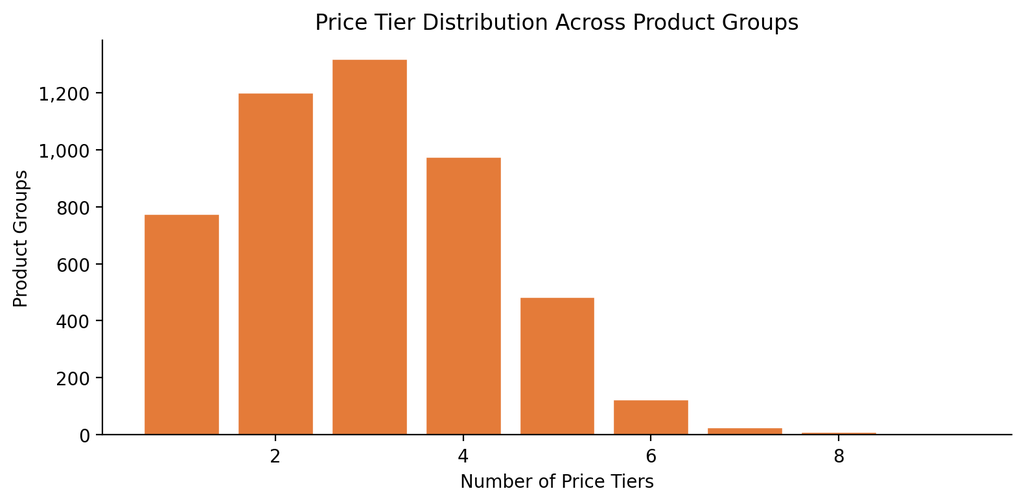

When V2 computes a z-score across a bimodal distribution, the global mean falls *between* the two tiers — making prices at both tiers look like outliers, while prices genuinely *between* tiers can appear normal.

# 3 How the Quantile Grid Works

The quantile grid replaces V2’s global statistics with a **structure-aware** approach: build a compact distribution sketch for each product group, find natural price gaps that separate purchasing modes, form tiers around those modes, then score each price against that structure. Instead of asking “is this price far from the mean?”, the grid asks “does this price belong to any established purchasing pattern?”

### 3.0.1 Algorithm Steps

1. **Build a 100-point quantile sketch.** For each product–account group, compute 101 quantiles (p0 through p100) from all purchase prices. This compresses millions of transactions into a compact distribution summary — 101 numbers that capture the full shape of the pricing curve. Groups with fewer than 3 purchases are excluded.
2. **Truncate to p5–p95.** Discard the bottom 5% and top 5% of the distribution. Extreme tails inflate the price range and mask real structure. Prices outside p5–p95 are automatically flagged as out-of-tier.
3. **Detect gaps.** Walk the remaining quantiles and measure each consecutive step. Any step ≥ 10% of the truncated range (p95 − p5) marks a boundary between distinct pricing modes. Up to 9 gaps are retained, largest first.
4. **Form tiers.** Split the quantile array at the detected gaps. Each segment becomes a tier defined by its lowest and highest quantile values. A price is “in-tier” if it falls within any tier’s range.
5. **Collapse thin tiers.** Tiers spanning fewer than 2 percentile points are too narrow to represent real purchasing patterns — they’re artifacts of sparse data. These are merged into the neighboring tier across the smaller gap.
6. **Score each candidate.** For each outlier candidate, find the nearest tier by midpoint distance and compute the deviation: `(price − tier_midpoint) / tier_midpoint × 100%`. Prices inside a tier get `in_tier = True`; prices in gaps or beyond the tier structure are flagged.

### 3.0.2 Worked Example

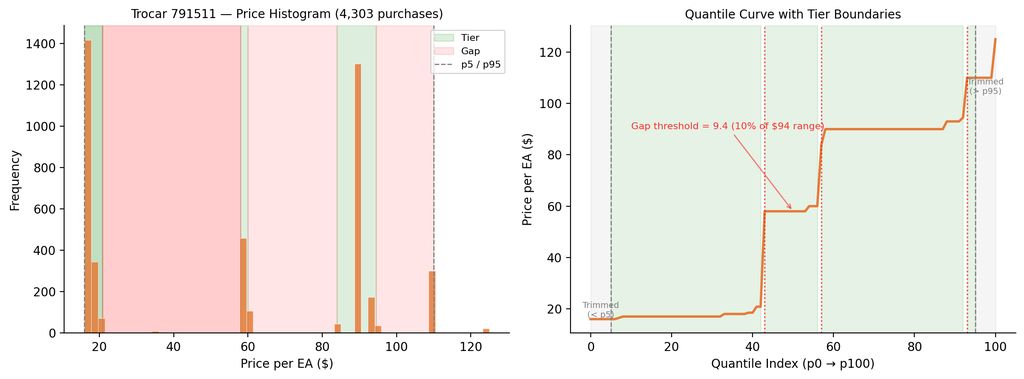

Figure 2: Trocar (Product 791511): Left — price histogram with tier ranges (green) and gaps (red). Right — quantile curve showing how gaps in the distribution map to tier boundaries.

### 3.0.3 Configuration Parameters

| Parameter | Value | Purpose |
| --- | --- | --- |
| Quantile points | 101 (p0–p100) | Resolution of the distribution sketch |
| Truncation range | p5–p95 | Removes extreme tails before analysis |
| Gap threshold | 10% of truncated range | Minimum gap size to split tiers |
| Max tiers | 10 | Prevents over-segmentation |
| Min tier width | 2 percentile points | Prevents single-point “tiers” |

# 4 Method Comparison

We compare three detection methods:

| Method | Approach | Speed | Multimodal? |
| --- | --- | --- | --- |
| **V1** | Legacy statistical rules | Fast | No |
| **V2** | 4-signal scoring (z, robust-z, percentile, deviation) | Fast | No |
| **Quantile Grid** | 100-point percentile sketch, gap-based tier detection, p5-p95 truncation | ~15s / 147M rows | Yes |

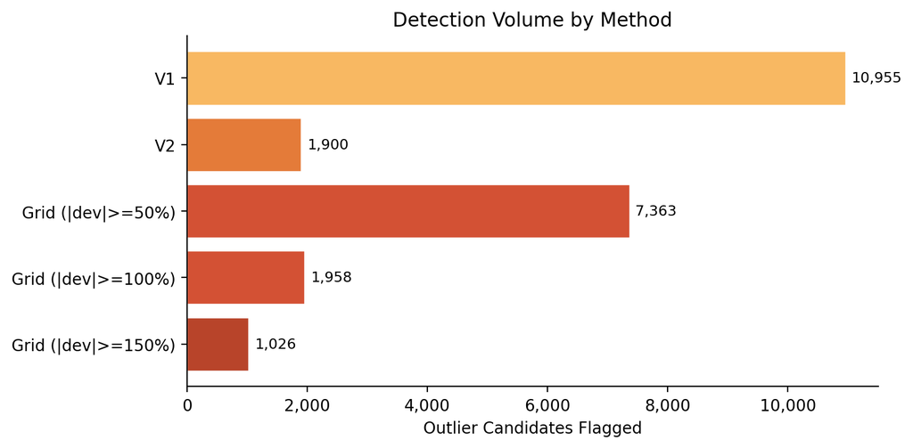

Figure 3: Outlier flags by method. V1 is the noisiest; V2 is more selective; the Grid (at |dev|>=100%) finds a middle ground.

## 4.1 Method Agreement

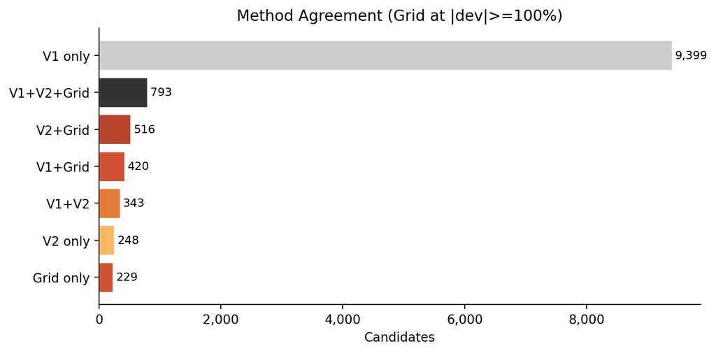

Figure 4: Most V1-only flags are noise that V2 correctly eliminated. Grid-only detections are new finds — mostly between-tier UOM anomalies that V2 can’t see.

# 5 P5–P95 Truncation

The quantile grid detects tier boundaries by finding **gaps that exceed 10% of the price range**. Sparse extreme values at p0 or p100 can inflate the range and hide real gaps, or create thin tiers that distort boundaries.

**Solution**: Truncate the distribution to **p5–p95** before doing anything — gap detection, tier boundaries, everything. Prices outside p5–p95 are automatically out-of-tier. One rule replaces the need for separate edge-correction mechanisms.

> **Example**: Product 1304722 has 9,399 purchases clustered at $41–$54, with a single $1.00 at p0 and $536 at p100. Using p0–p100, the range is $535, making the $40 gap at $1→$41 invisible (7.5% < 10% threshold). Using p5–p95, the range is $12.45 and the gap is 323% — obvious. The $1.00 and $536 are automatically out-of-tier.

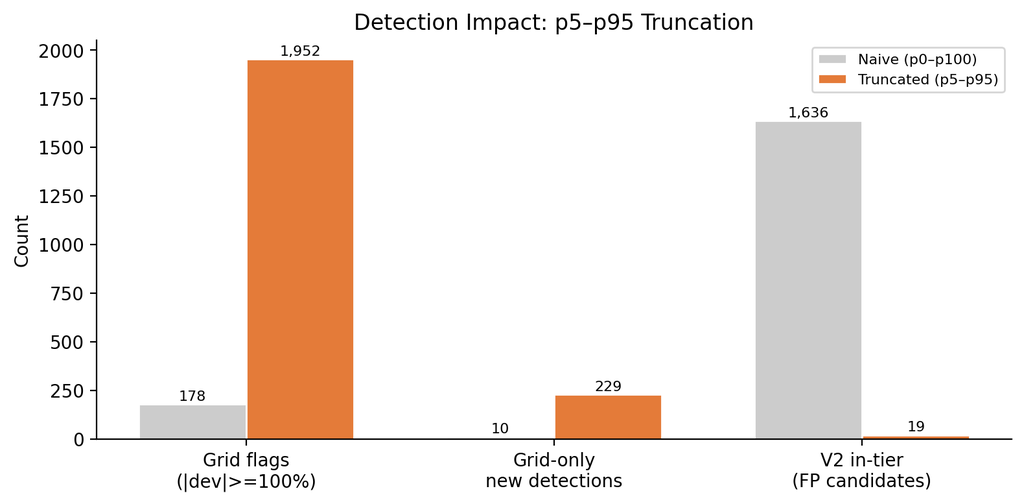

Figure 5: Impact of p5-p95 truncation. V2 false positives drop from 1,636 (naive) to 19. Grid detections increase significantly as real gaps are no longer hidden by extreme values.

## 5.1 Example: Product 1304722

**Sterile Wound Irrigation** — 9,399 purchases clustered at $41–$54, with a single $1.00 and a $536 at the extremes.

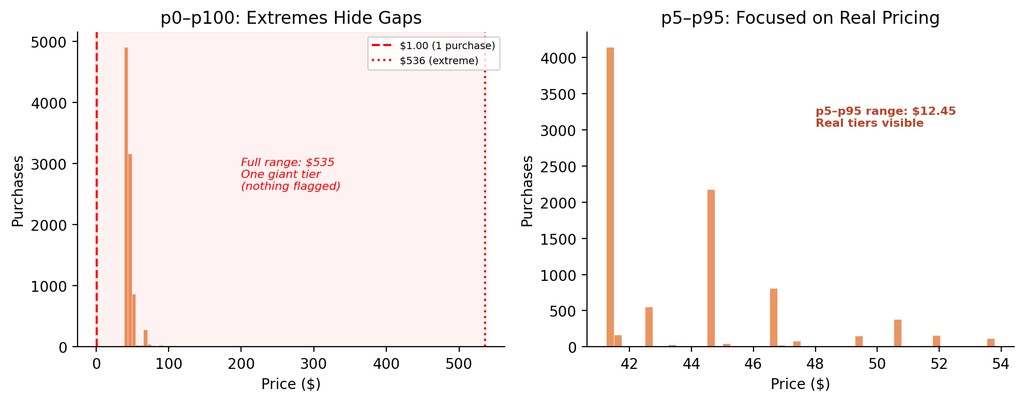

Figure 6: Product 1304722: Using p0–p100 (left), the $1 and $536 inflate the range, hiding real gaps. Using p5–p95 (right), the distribution is focused on the real pricing cluster.

# 6 V2 False Positives

**Only 19 V2 outliers sit inside established price tiers** after p5–p95 truncation. These are candidates where V2’s unimodal statistics flag the price as unusual, but the quantile grid shows the price matches a known purchasing pattern.

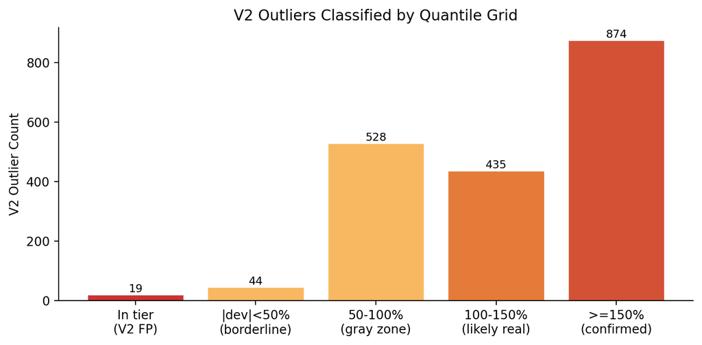

Figure 7: V2 outliers classified by quantile grid. Only 19 are inside a known price tier — down from 1,636 with naive (p0–p100) tier detection.

## 6.1 V2 Gaussian Noise: Multimodal Examples

V2’s z-score assumes a single bell curve. When a product has two or more price tiers, the mean falls *between* them — making prices at the upper tier look like outliers even though they represent a real purchasing pattern.

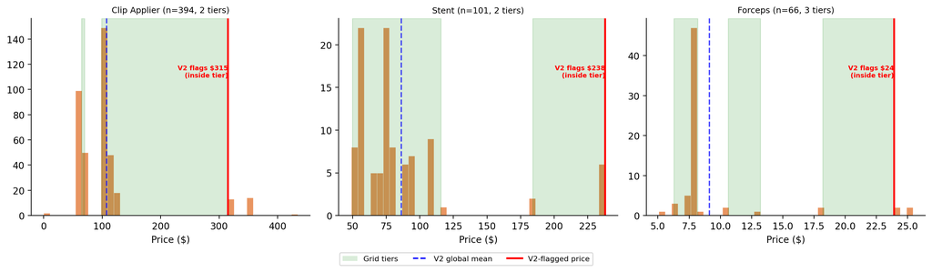

Figure 8: Three products where V2 flags prices that sit inside a valid tier. In each case, the product has multiple price modes, and V2’s global mean (dashed blue) lands between them — flagging the upper tier as ‘anomalous’.

In each case, the flagged price sits comfortably inside a tier (green shading). V2’s global mean (blue dashed line) falls between the tiers — making the upper tier appear anomalous. The quantile grid correctly identifies these as **normal purchases at a different price tier**.

## 6.2 Grid Interior Outliers: Between-Tier Detection

The grid’s tier structure also catches prices that fall *between* valid tiers — genuine anomalies that V2 often misses because they don’t deviate enough from the global mean.

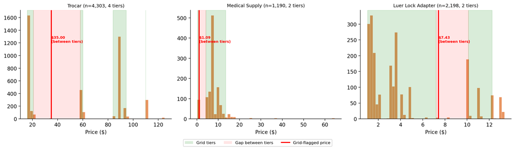

Figure 9: Three products where the grid catches prices in the gap between tiers. These are genuine anomalies — prices that don’t match any established purchasing pattern. V2 missed all three.

These prices land in no-man’s-land — too high for one tier, too low for the next. V2 doesn’t flag them because they’re not extreme relative to the global distribution, but they don’t match any real purchasing pattern.

# 7 Catalog UOM Audit

Broadjump maintains two UOM-related tables: a **product catalog** (UOM codes and pack sizes) and a **threshold table** (expected price ranges per UOM). Cross-referencing these tables revealed **894 internal violations** where the tables contradict each other.

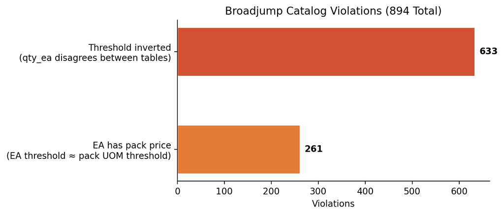

Figure 10: 894 violations across two types. Threshold inversions (qty_ea disagrees between tables) dominate; EA-has-pack-price violations indicate the EA row was entered at pack-level pricing.

## 7.1 Violation Types

**`threshold_inverted`**: The threshold table’s pack-size quantity (`uomquantity`) disagrees with the product catalog’s quantity (`quantityofeainuom`). When these quantities are wrong, threshold ranges invert — a BX that should cost more than EA shows a *lower* threshold instead.

**`ea_has_pack_price`**: The EA row in the threshold table has a price range that matches a pack-level UOM. The “per-each” threshold is actually a per-box or per-case price.

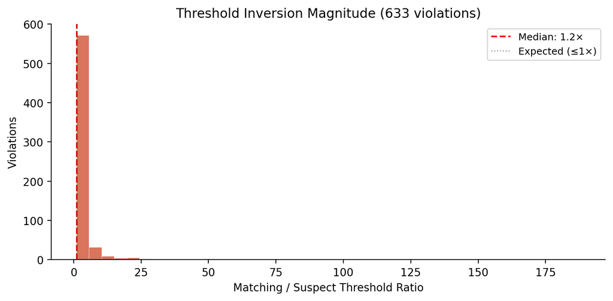

## 7.2 Example: EA with Pack-Level Pricing

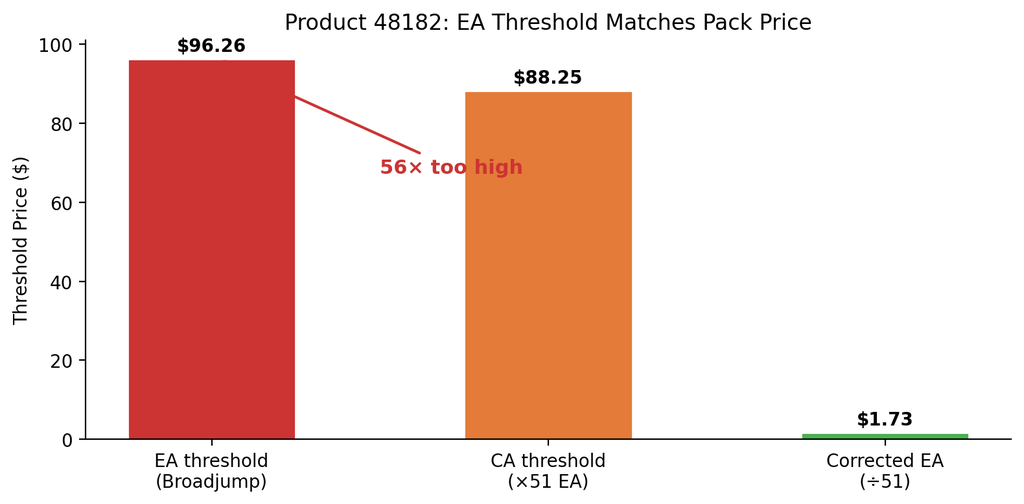

Figure 12: A product where the EA threshold in Broadjump’s table matches the pack UOM threshold — the EA row was entered at pack-level pricing. The corrected EA price (dividing by pack size) is far lower.

**WarningCatalog Cleanup Needed**

All 894 violations have been exported for Broadjump review. These errors affect downstream threshold-based UOM matching and should be corrected at the source.

# 8 Catalog-Backed UOM Explanations

Using the corrected catalog thresholds, we can automatically explain **252 outlier candidates** as UOM mismatches — prices that are outliers relative to the per-EA price grid but match an expected pack-size price from the catalog.

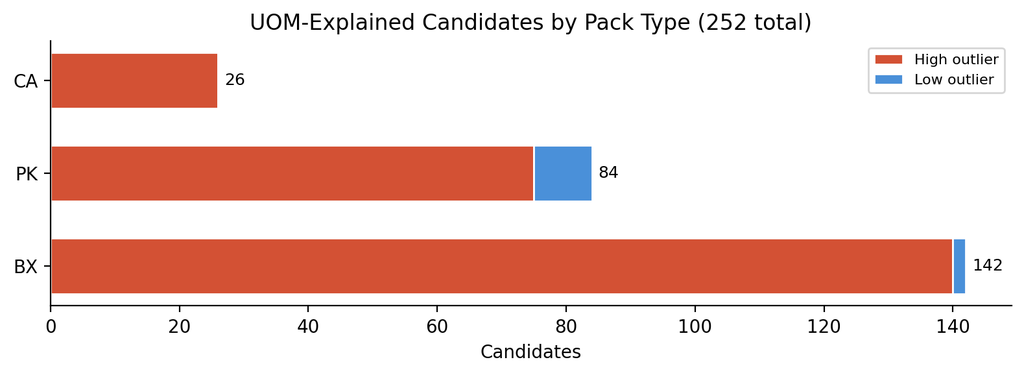

## 8.1 Example: UOM Mismatch Detection

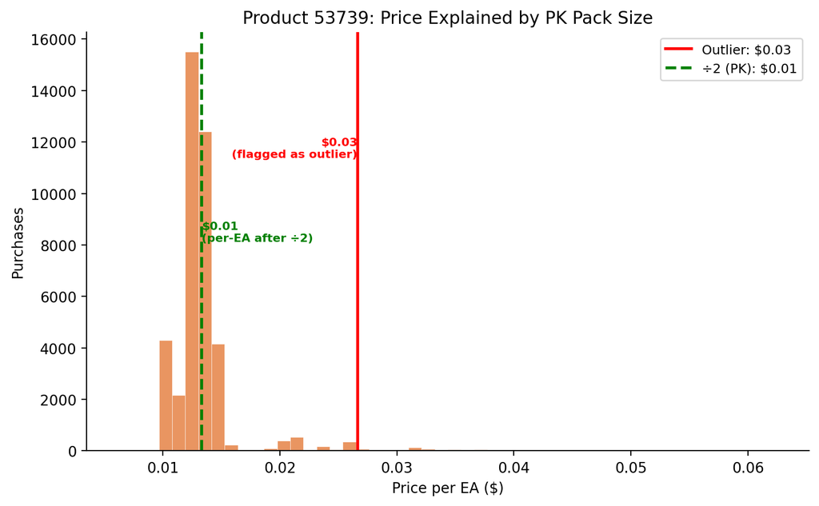

Figure 14: A high-outlier price explained by pack-size matching. The outlier price (red) is anomalous on the per-EA distribution, but dividing by the pack size (green dashed) places it squarely in the main purchasing cluster.

## 8.2 Highest-Value UOM Explanations

shape: (5, 6)

| ProductID i64 | Description str | Price f64 | Matched UOM str | Pack Size i64 | Total Spend ($) f64 |
| --- | --- | --- | --- | --- | --- |
| 53739 | null | 0.03 | "PK" | 2 | null |
| 644891 | null | 322.0 | "BX" | 6 | null |
| 831132 | null | 0.04 | "PK" | 2 | null |
| 831132 | null | 0.04 | "PK" | 2 | null |
| 831132 | null | 0.04 | "PK" | 2 | null |

**TipProduction-Ready**

These 252 UOM explanations use Broadjump’s own catalog thresholds — no synthetic heuristics. They can be surfaced directly to reviewers as automated explanations alongside the outlier flag.

# 9 Outlier Classification

All 15,203 candidates classified into severity tiers based on where each price falls in its product’s overall distribution.

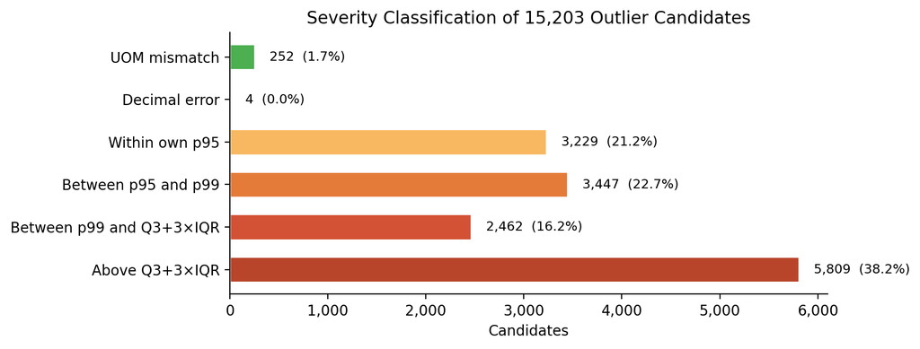

Figure 15: All 15,203 candidates classified by severity. Explained categories (UOM, decimal) are at top; unexplained tiers are ordered from mild (within p95) to extreme (beyond Tukey fence). The largest group — genuine extremes above Q3+3×IQR — should be the review priority.

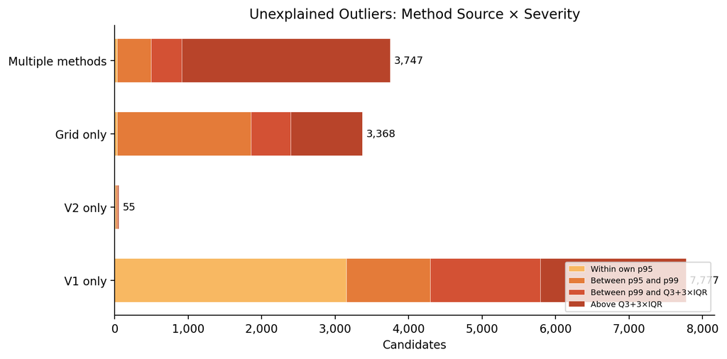

Figure 16: Unexplained outliers broken down by detection method and severity. Multi-method agreement concentrates in the severe tiers — these are the highest-confidence, highest-priority candidates.

**NotePriority for Review**

Focus on the **Above Q3+3×IQR** tier — these are prices beyond the Tukey fence for their product, confirmed extreme by multiple independent statistical measures. Multi-method candidates in this tier are the highest-value cases.

# 10 Facility-Level Analysis

We investigated whether facility-level purchasing patterns (UOM mix, volume) could explain the remaining outliers. The answer: **no** — but the investigation produced useful insights about the pipeline.

## 10.1 Hypothesis: Facility UOMs Explain Outliers

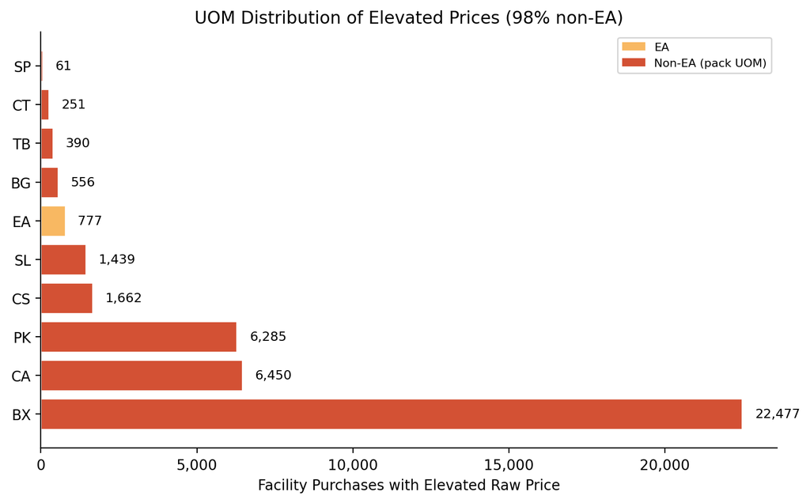

Figure 17: UOM distribution of facility purchases with elevated raw prices (>2× product median). Most high raw prices are non-EA UOMs — but this is expected, not an error.

Initial finding: most elevated raw prices *are* non-EA UOMs. But this is a **red herring** — the pipeline already normalizes to per-EA before outlier detection.

## 10.2 The Pipeline Already Normalizes to Per-EA

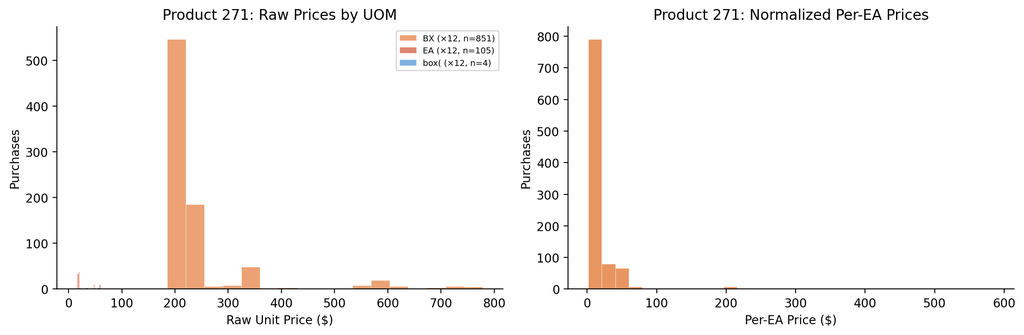

Figure 18: Raw unit prices vary dramatically by UOM (left), but after dividing by UOM conversion factor, the per-EA prices converge (right). The pipeline performs this normalization before outlier detection.

The raw prices separate cleanly by UOM (left), but after per-EA normalization (right), they converge. **The pipeline already does this conversion** — so high raw prices from pack UOMs are *not* the source of outliers.

## 10.3 Volume Doesn’t Explain It Either

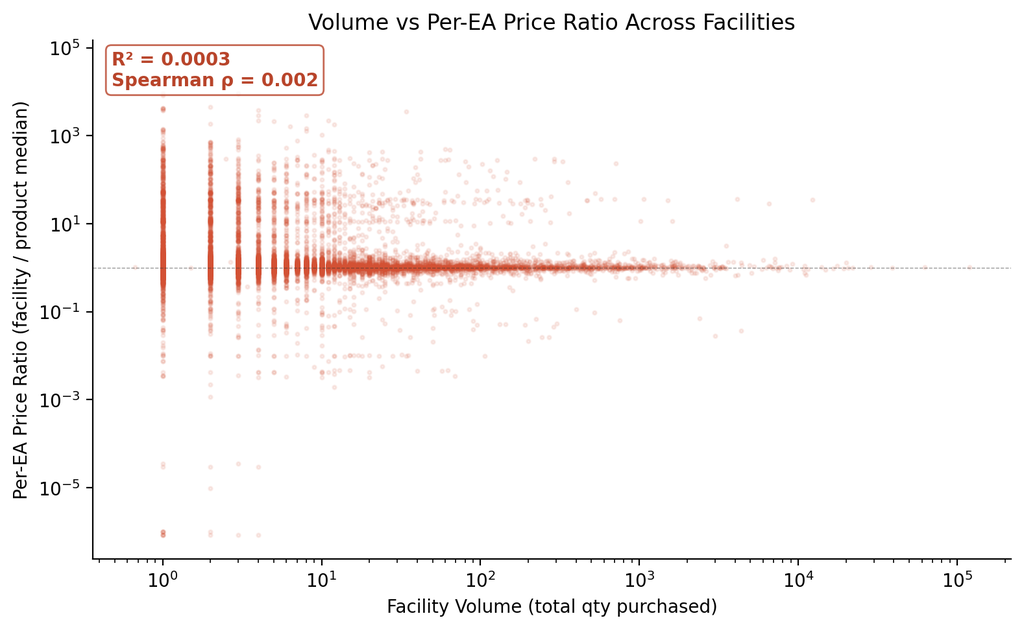

Figure 19: Per-EA price ratio vs facility purchase volume — essentially no correlation. Volume-based pricing is not a significant driver of the remaining outliers.

## 10.4 Customer-Level Tier Consistency

Customers negotiate contract prices, and their facilities buy at those prices. If most facilities within a customer land on the same price tier, then a facility on a *different* tier is a high-signal outlier — it suggests a billing error or contract exception.

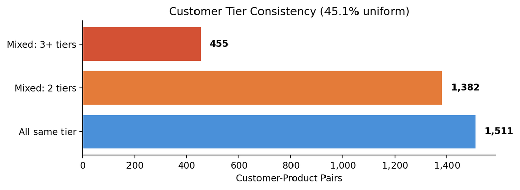

**TipExample: JH / Product 1116945**

For one large customer (JH), 16 of 17 facilities purchasing Product 1116945 land on Tier 1. The single off-tier facility is a strong candidate for a billing correction. The new `suggested_price` column in the export provides the customer’s normal price for easy comparison.

**ImportantKey Conclusion**

# 11 Actionable Findings

We explored every structural dimension of the 14,947 unexplained outlier candidates — product category, price multiples, temporal patterns, geographic variation, customer concentration, vendor data quality, and method agreement. The sections below present the dimensions that carry actionable signal, ranked by business impact. Dimensions that showed no signal (product category, time patterns, geographic variation, price precision) are documented in Appendix A for completeness.

## 11.1 Root Cause: UOM Conversion Failures

The outlier detection pipeline operates on `PriceEA` — the per-each price after UOM normalization. But examining the upstream facility transaction data (which preserves the original UOM code and conversion factor) reveals the dominant root cause: **most high outlier prices are pack-level UOM purchases with broken conversion factors**.

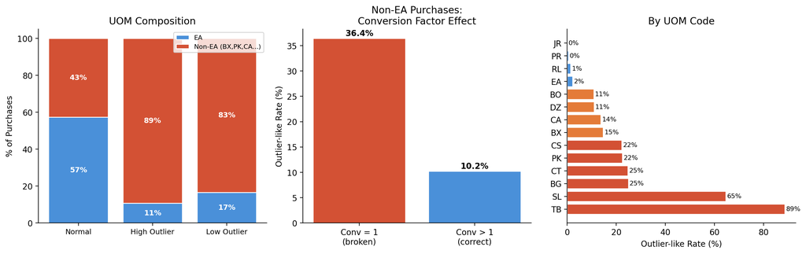

Figure 21: 89% of high-priced outlier purchases are non-EA UOMs (boxes, packs, cases), compared to 43% for normal purchases. When the UOM conversion factor is 1 (treating pack price as EA), the outlier rate jumps to 36%.

The pattern is stark: **non-EA purchases with conversion factor = 1 have a 36.4% outlier rate** versus 10.2% for properly converted non-EA purchases and just 2.2% for EA purchases. The UOM codes TB (tube, 89%), SL (sleeve, 65%), and PK (pack, 22%) are the worst offenders — these are pack-level prices passing through as per-EA because the conversion factor is missing or set to 1.

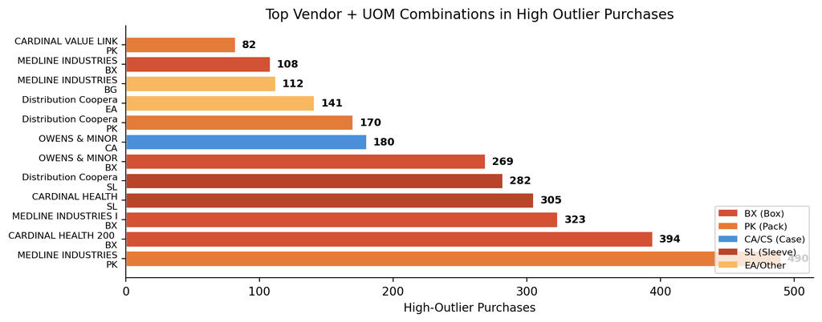

Figure 22: Distributor + UOM combinations driving high outlier purchases. Medline packs (PK), Cardinal boxes (BX), and Owens & Minor boxes/cases dominate — these are pack-level prices from distributors where the UOM conversion wasn’t applied.

**ImportantRoot Cause: UOM Conversion Failures**

The pipeline receives `PriceEA` — already normalized. But the upstream data shows that most “unexplained” high outliers originate as **pack-level purchases (BX, PK, CA) where the UOM conversion factor is 1** instead of the actual pack size. The pack price passes through as an EA price, creating the outlier.

This means:

- **The outliers are real** — the per-EA price in the pipeline is genuinely wrong
- **The fix is upstream** — correct the UOM conversion factors in the transaction data
- **The top distributors to audit**: Medline (PK), Cardinal Health (BX/SL), Owens & Minor (BX/CA), Distribution Cooperative (SL/PK)
- **The worst UOM codes**: TB (89% outlier rate), SL (65%), PK/CT (~23%), BX (15%)

## 11.2 Vendor Data Quality

The UOM root cause points to specific vendor data feeds as the upstream fix. Not all vendors are equally broken — a handful of distributors account for the vast majority of conversion failures.

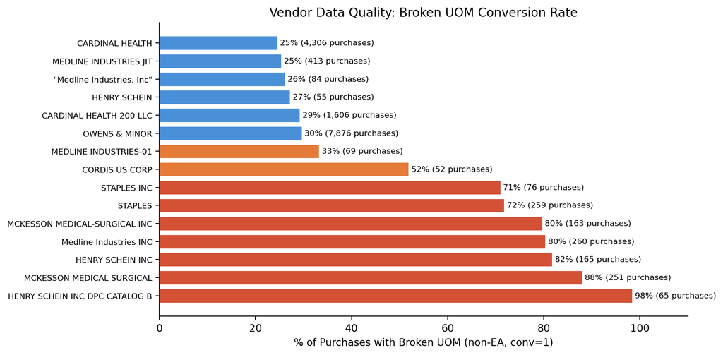

Figure 23: Broken UOM rate by vendor (non-EA purchases with conversion factor = 1, minimum 50 purchases). Henry Schein, McKesson, and Medline have 80–99% broken conversions — fixing these 4–5 vendor feeds would eliminate a large fraction of UOM failures.

**TipActionable: Fix 4–5 Vendor Feeds**

Correcting UOM conversions in the Henry Schein, McKesson, Medline, and Owens & Minor data feeds would eliminate a large fraction of UOM-driven outliers. These are systematic data quality problems in the vendor interface, not random errors.

## 11.3 Customer Materiality Dashboard

Outlier candidates are not evenly distributed across customers. A small number of health systems generate disproportionate candidate counts — some due to UOM data quality, others due to facility-level pricing misconfigurations.

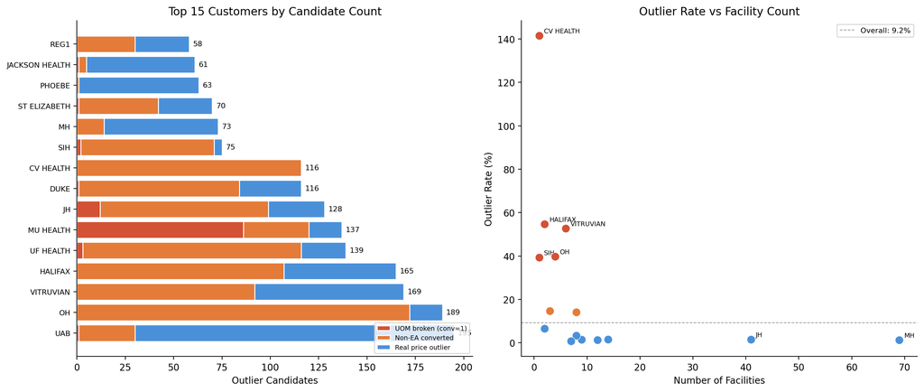

**NoteCustomer Concentration**

The top 10 customers account for ~91% of matched facility spend on outlier products. Customer-level remediation — whether fixing UOM feeds or correcting pricing configurations — is far more efficient than reviewing candidates individually.

## 11.4 Dollar Exposure Scoring

Not all 15,203 candidates are equal. A candidate’s **dollar exposure** — the estimated spend at risk if the pricing deviation is real — combines error magnitude with business materiality into a single actionable number:

$$\text{exposure} = \text{spend} \times \frac{|\text{deviation}\%|}{100 + |\text{deviation}\%|}$$

A product with $1M in spend at 200% deviation has $667K in estimated exposure. This directly answers the business question: **how much money is at risk?**

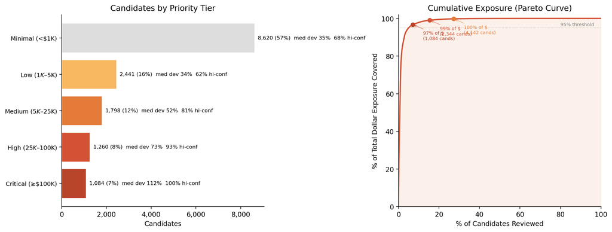

Figure 25: Dollar exposure tiers concentrate the review workload. The top 1,084 critical candidates (>$100K exposure each) account for $3.0B — reviewing just 7% of candidates covers 97% of the dollar risk.

The **critical tier** (≥$100K exposure) contains the candidates where both the pricing deviation and the transaction volume are large enough to represent meaningful dollar risk. The Pareto curve shows the concentration: reviewing just the top few percent of candidates covers the vast majority of the exposure.

### 11.4.1 Top Products by Dollar Exposure

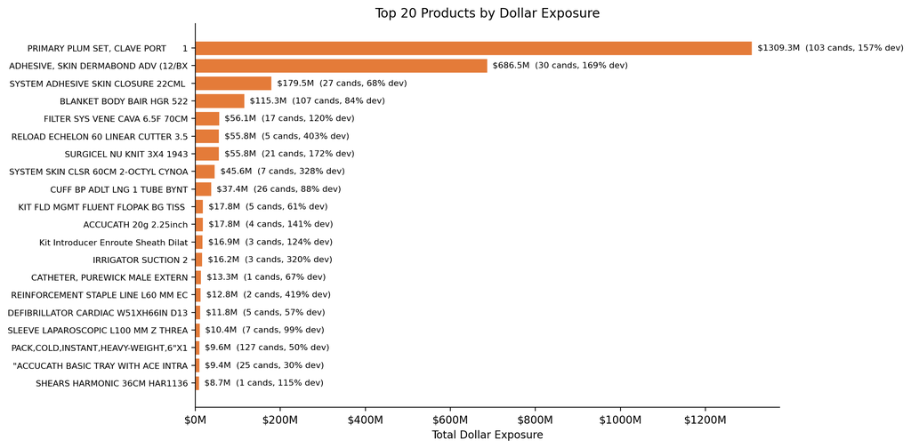

Figure 26: Top 20 products by total dollar exposure. These products account for the bulk of the review workload — resolving pricing on even a handful would substantially reduce total exposure.

The product-level view deduplicates candidates that appear across multiple customer groups. Resolving pricing for just the top handful of products would substantially reduce total exposure — the concentration is steep.

## 11.5 Integer-Multiple Price Patterns

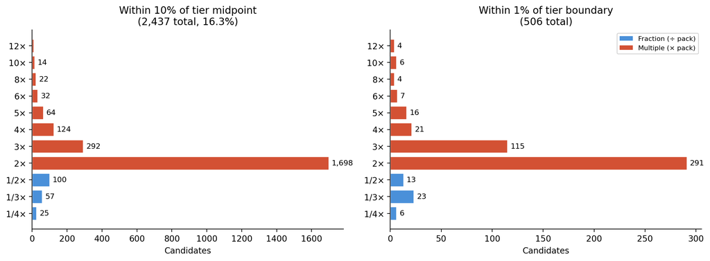

Figure 27: 16.3% of unexplained outlier prices are near-integer multiples of the nearest tier price — strongly suggestive of UOM errors that lack catalog confirmation. The 2× cluster alone contains 1,698 candidates.

**TipExample: Exact 2× Matches**

Spinal rods at $700.00 = exactly 2 × $350.00 tier boundary. BP cuffs at $4.40 = exactly 2 × $2.20. These are pack-of-2 prices entered as EA.

## 11.6 Repeat Offender Products

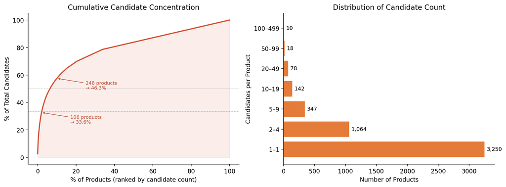

Figure 28: A small number of high-volume products generate a disproportionate share of candidates. 106 products (2% of all) account for 33.6% of candidates.

Table 2: Top 15 repeat offender products — high-volume items where many facilities buy at slightly different prices.

shape: (15, 7)

| ProductID i64 | description str | category str | n_candidates u32 | unique_prices u32 | tiers i64 | med_dev_% f64 |
| --- | --- | --- | --- | --- | --- | --- |
| 33176 | "SWAB ORAL TOOTHETTE PLUS SODIU… | "Patient Care & Cleansing " | 408 | 3 | 4 | 0.0 |
| 1310066 | "SLIPPER PT PLLW PAW X-LRG" | "Patient Footwear" | 135 | 1 | 4 | 3.0 |
| 794845 | null | "Flush Syringes" | 128 | 3 | 4 | 54.0 |
| 833445 | "PACK,COLD,INSTANT,HEAVY-WEIGHT… | "Hot & Cold Therapy" | 127 | 2 | 2 | 50.0 |
| 833238 | null | "General Wound Care" | 116 | 2 | 1 | 63.0 |
| … | … | … | … | … | … | … |
| 819749 | "WIPE TOWELETTE CASTILE SOAP" | "Patient Care & Cleansing " | 99 | 1 | 5 | 0.0 |
| 5086633 | null | "Surgical Power Equipment" | 99 | 1 | 1 | 77.0 |
| 1015693 | "PADPRO ELECTRODE DEFIB W CNCTR" | "Ecg/Ekg Electrodes & Acce" | 97 | 2 | 3 | 1.0 |
| 2964204 | "SCREW LOCK SQUARE 2.7X16MM" | "Ortho - Trauma" | 85 | 3 | 3 | 5.0 |
| 43203 | "USP - United States Pharmacope… | "Bulk & Cylinder Medical G" | 85 | 2 | 1 | 7.0 |

The concentration is extreme: **106 products generate 33.6% of all candidates**, and **248 products generate 46.3%**. Most are high-volume commodities (oral swabs, slippers, cold packs, gauze) where many facilities buy at slightly different prices. Reviewing these as a batch — rather than evaluating each candidate individually — would be far more efficient.

**NoteActionable Findings Summary**

[output not shown]